# Tara reade - Análisis exploratorio

Martín Pons

5/6/2020

Análisis del tópico Tara Reade

Tara Reade es una antigua empleada del candidato a la presidencia, Joe Biden. Durante el periodo de recogida de datos, Reade acuso publicamente al candidato de abusos sexuales en los 90. Se ha recogido información de twitter con este tópico para analizar la reacción de las comunidades

```r
# librerias
library(qdapRegex)
library(sentimentr)
library(syuzhet)
library(lubridate)
library(tidyverse)
library(tidytext)
library(forcats)
library(tokenizers)
library(widyr)
library(igraph)
library(ggraph)
library(topicmodels)
library(forcats)
library(scales)
library(stringr)
library(extrafont)
library(reldist)
library(grid)
library(gridExtra)
library(boot)
library(ggradar)
library(tidygraph)
library(boot)
library(sp)
library(spData)
library(ggmap)
library(rgdal)
library(rgeos)
library(tmap)


# Sys.getenv()
Sys.setenv(JAVA_HOME = "C:\\Program Files\\Java\\jre1.8.0_251")

library(tm)
library(qdap)

# funciones auxiliares
source(here::here("scripts", "funciones_auxiliares.R"))

# paleta
plots_palette <- c("#ad5d51", "grey55", "#2b559e", "#947240")

# orden comunidades
comunidad_order <- c("GOP", "Independent", "DNC", "Progressives")
```

Estos datos han sido previamente procesados, sobre todo en lo que se refiere al texto de los tweets. Se excluyen términos relacionados con la pandemia que provoca la enfermedad COVID-19 (en el texto sin limpiar, hay un número amplio de términos para referirse a la enfermedad. Se han unificado todos en el término COVID19).

Se ha recogido también información sobre los seguidores de cuentas para definir 4 comunidades

- GOP: Seguidores de la cuenta del partido republicano, que no siguen la cuenta del partido demócrata ni del movimiento progresista
- DNS: Seguidores de la cuenta del partido demócrata, que no siguen la cuenta del partido republicano ni del movimiento progresista
- Progressives: Seguidores de la cuenta del movimiento progresista, que no siguen la cuenta del partido republicano ni del partido demócrata
- Independent: usuarios de tweets recogidos que no se encuentran incluidos en ninguno de los casos anteriores

```r
# CARGA DE DATOS  Y FORMATO  ----------------------------------------------------------
library(tidyverse)


# carga y formato basico
tara <- readRDS(here::here("datos_procesados", "formated_text_df_data", "taradreade_no_sent.rds")) %>%
  filter(str_detect(text, "#?covid19|#?COVID|#?[Pp]andemic|#trumpvirus", negate = T)) %>%
  mutate(comunidad = fct_relevel(comunidad, c("GOP", "Independent", "DNC", "Progressives")),
         user_id = as.character(user_id))
```

## Distribucion de tweets

```r
tara %>%
  count(comunidad) %>%
  mutate(f = percent(n/sum(n), accuracy = 0.1))
```

```
## # A tibble: 4 x 3
##   comunidad        n f
##   <fct>        <int> <chr>
## 1 GOP          36717 21.6%
## 2 Independent  98692 58.2%
## 3 DNC          18715 11.0%
## 4 Progressives 15557 9.2%
```

```r
freq_tweets_usuario <- get_tweet_distribution(tara)

freq_tweets_usuario %>%
  arrange(desc(tweets)) %>%
  mutate(tweets_acum = cumsum(tweets),
         usuarios_acum = cumsum(usuarios)) %>%
  mutate(por_tweets_acum = tweets_acum / sum(tweets),
         por_usuarios_acum = usuarios_acum / sum(usuarios)) %>%
  mutate(int_users_acum = cut(por_usuarios_acum, breaks = seq(0, 1, by = 0.05))) %>%
  group_by(comunidad, int_users_acum) %>%
  summarise(porc_tweets = sum(porc_tweets)) %>%
  mutate(porc_tweets_acum = cumsum(porc_tweets))
```

```
## # A tibble: 28 x 4
## # Groups:   comunidad [4]
##    comunidad   int_users_acum porc_tweets porc_tweets_acum
##    <fct>       <fct>                <dbl>            <dbl>
##  1 GOP         (0,0.05]          0.985               0.985
##  2 GOP         (0.05,0.1]        0.0105              0.995
##  3 GOP         (0.1,0.15]        0.00140             0.996
##  4 GOP         (0.15,0.2]        0.00117             0.998
##  5 GOP         (0.2,0.25]        0.000935            0.999
##  6 GOP         (0.25,0.3]        0.000701            0.999
##  7 GOP         (0.45,0.5]        0.000468            1.00
##  8 GOP         (0.95,1]          0.000234            1
##  9 Independent (0,0.05]          0.994               0.994
## 10 Independent (0.05,0.1]        0.00353             0.997
## # ... with 18 more rows
```

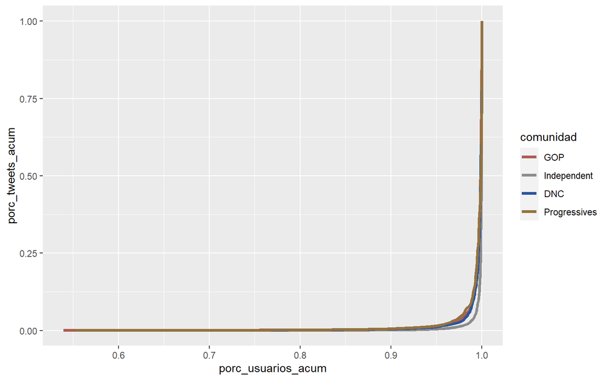

```r
# Curva de lorenz
freq_tweets_usuario %>%
  ggplot(aes(x = porc_usuarios_acum, y = porc_tweets_acum)) +
  geom_line(aes(color = comunidad), size = 1.3) +
  scale_color_manual(values = plots_palette)
```

```r
# gini
gini_comunidades <- freq_tweets_usuario %>%
  group_by(comunidad) %>%
  summarise(gini = gini(x = tweets, weights = porc_usuarios)) %>%
  arrange(desc(gini))
```

## Analisis de Topic

### Hashtags más usados

De los hashtags utilizados se ve claramente el posicionamiento de cada comunidad en relación a este tema. No parecen surgir temas específicos entre los hashtags. En el bando republicano, algunos hashtags parecen hacer referencia a una supuesta hipocresía de los liberales.

```r
tara <- tara %>%
  filter(comunidad != "Independent")

# datos tidy
tara_unigram <- get_unigrams(tara, c("#tarareade", "#tara", "tara", "#reade", "reade"))
tara_hashtag <- get_hashtags(tara_unigram)
tara_frequency <- get_frequencies(tara_hashtag)



## Topics con networks ##

gop_tara_net <- create_hashtag_graph(tara_hashtag, "GOP", c("#tarareade", "#tara", "tara", "#reade", "reade"), minim_n = 3, nodos_n = 20)
```

```
## Iniciacion data frame de links
## Obtencion de data frame con conteo de hashtag  por status_id
## Obtencion de data frame de frequencias de hasthags
## Obtencion del porcentade de usuarios del hashtag
## Filtro de datos por nodos mas frecuentes
## Obtencion de tweets unicos
## Inicio de loop para obtener data frame de links
## [1] "Nodo: 1  -  #metoo"
## [1] "Nodo: 2  -  #joe"
## [1] "Nodo: 3  -  #foxnews"
## [1] "Nodo: 4  -  #metoounlessitsbiden"
## [1] "Nodo: 5  -  #believeallwomen"
## [1] "Nodo: 6  -  #biden"
## [1] "Nodo: 7  -  #ibelievetarareade"
## [1] "Nodo: 8  -  #creepyjoe"
## [1] "Nodo: 9  -  #kavanaugh"
## [1] "Nodo: 10  -  #trump2020"
## [1] "Nodo: 11  -  #election2020"
## [1] "Nodo: 12  -  #dementiajoe"
## [1] "Nodo: 13  -  #dropoutbiden"
## [1] "Nodo: 14  -  #obamagate"
## [1] "Nodo: 15  -  #biden2020"
## [1] "Nodo: 16  -  #smartnews"
## [1] "Nodo: 17  -  #fakenews"
## [1] "Nodo: 18  -  #democrats"
## [1] "Nodo: 19  -  #kag"
## [1] "Nodo: 20  -  #kag2020"
## [1] "Nodo: 21  -  #sleepyjoe"
## Fin de loop
## Adicion de nodos sin links
## Wrangling final del data frame
## Devolucion del data frame
```

```r
dnc_tara_net <- create_hashtag_graph(tara_hashtag, "DNC",  c("#tarareade", "#tara", "tara", "#reade", "reade"), minim_n = 3, nodos_n = 20)
```

```
## Iniciacion data frame de links
## Obtencion de data frame con conteo de hashtag  por status_id
## Obtencion de data frame de frequencias de hasthags
## Obtencion del porcentade de usuarios del hashtag
## Filtro de datos por nodos mas frecuentes
## Obtencion de tweets unicos
## Inicio de loop para obtener data frame de links
## [1] "Nodo: 1  -  #biden2020"
## [1] "Nodo: 2  -  #metoo"
## [1] "Nodo: 3  -  #joe"
## [1] "Nodo: 4  -  #trump"
## [1] "Nodo: 5  -  #ridenwithbiden"
## [1] "Nodo: 6  -  #ibelievebiden"
## [1] "Nodo: 7  -  #ibelievejoe"
## [1] "Nodo: 8  -  #tarareadeisaliar"
## [1] "Nodo: 9  -  #biden"
## [1] "Nodo: 10  -  #smartnews"
## [1] "Nodo: 11  -  #gojoe"
## [1] "Nodo: 12  -  #ridinwithbiden"
## [1] "Nodo: 13  -  #tarareadeisafraud"
## [1] "Nodo: 14  -  #tarareades"
## [1] "Nodo: 15  -  #foxnews"
## [1] "Nodo: 16  -  #morningjoe"
## [1] "Nodo: 17  -  #berniebros"
## [1] "Nodo: 18  -  #tarareadee28099s"
## [1] "Nodo: 19  -  #ibelievetarareade"
## [1] "Nodo: 20  -  #believewomen"
## Fin de loop
## Adicion de nodos sin links
## Wrangling final del data frame
## Devolucion del data frame
```

```r
prg_tara_net <- create_hashtag_graph(tara_hashtag, "Progressives",  c("#tarareade", "#tara", "tara", "#reade", "reade"), minim_n = 3, nodos_n = 20)
```

```
## Iniciacion data frame de links
## Obtencion de data frame con conteo de hashtag  por status_id
## Obtencion de data frame de frequencias de hasthags
## Obtencion del porcentade de usuarios del hashtag
## Filtro de datos por nodos mas frecuentes
## Obtencion de tweets unicos
## Inicio de loop para obtener data frame de links
## [1] "Nodo: 1  -  #metoo"
## [1] "Nodo: 2  -  #ibelievetarareade"
## [1] "Nodo: 3  -  #dropoutbiden"
## [1] "Nodo: 4  -  #joe"
## [1] "Nodo: 5  -  #joemustgo"
## [1] "Nodo: 6  -  #ibelievebiden"
## [1] "Nodo: 7  -  #timesupbiden"
## [1] "Nodo: 8  -  #believewomen"
## [1] "Nodo: 9  -  #releasetarafiles"
## [1] "Nodo: 10  -  #neverbiden"
## [1] "Nodo: 11  -  #biden"
## [1] "Nodo: 12  -  #ibelievetara"
## [1] "Nodo: 13  -  #bluemaga"
## [1] "Nodo: 14  -  #bernie"
## [1] "Nodo: 15  -  #dropoutjoe"
## [1] "Nodo: 16  -  #replacebiden"
## [1] "Nodo: 17  -  #bernieunsuspend"
## [1] "Nodo: 18  -  #believeallwomen"
## [1] "Nodo: 19  -  #tarareades"
## [1] "Nodo: 20  -  #berniecomeback"
## Fin de loop
## Adicion de nodos sin links
## Wrangling final del data frame
## Devolucion del data frame
```

```r
tara_graph <- bind_graphs(gop_tara_net, dnc_tara_net, prg_tara_net) %>%
  activate(nodes) %>%
  mutate(comunidad = fct_relevel(comunidad, c("GOP", "DNC", "Progressives"))) %>%
  activate(edges) %>%
  filter(strength > 3) %>%
  activate(nodes) %>%
  mutate(degree = centrality_degree())
```

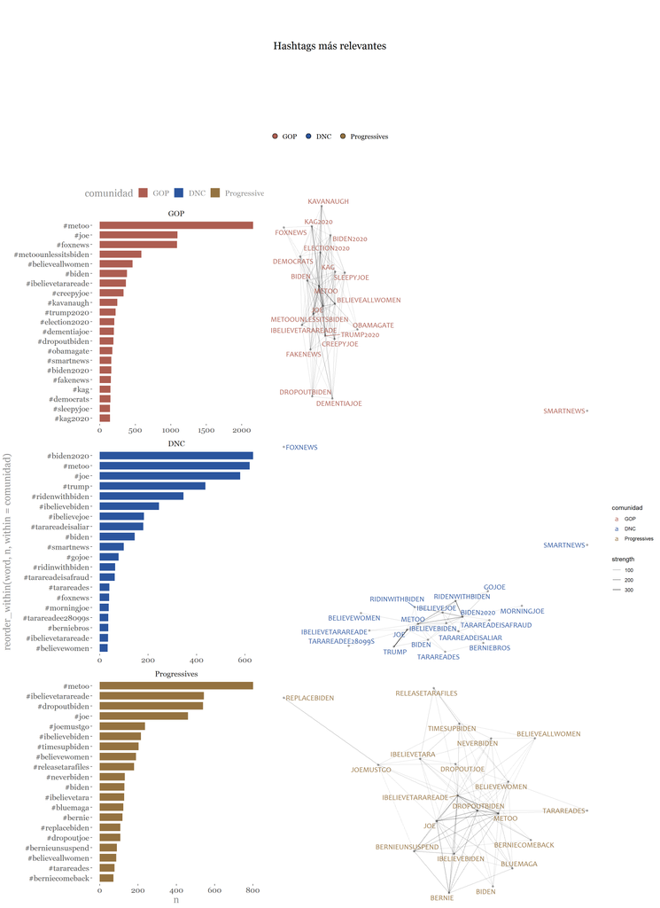

```r
library(qdapRegex)
library(sentimentr)
library(syuzhet)
library(lubridate)
library(tidyverse)
library(tidytext)
library(forcats)
library(tokenizers)
library(widyr)
library(igraph)
library(ggraph)
library(topicmodels)
library(forcats)
library(scales)
library(stringr)
library(extrafont)
library(reldist)
library(grid)
library(gridExtra)
library(boot)
library(ggradar)
library(tidygraph)
library(boot)
library(sp)
library(spData)
library(ggmap)
library(rgdal)
library(rgeos)
library(tmap)

# además de hastgags reivindicativos como #taxtherich# makebillionarespay# pr
plot_topic_networks(tara_frequency, tara_graph, filtered_words = c("#tara", "tara", "#reade", "reade"),
                    texto_titulo = "Hashtags más relevantes", lab_size = 17, text_size = 4.5, layout_style = "nicely", minim_n = 3)
```

### Temas propios de comunidades

Se intensifican los tópicos descubiertos en el gráfico anterior

#### Hashtags

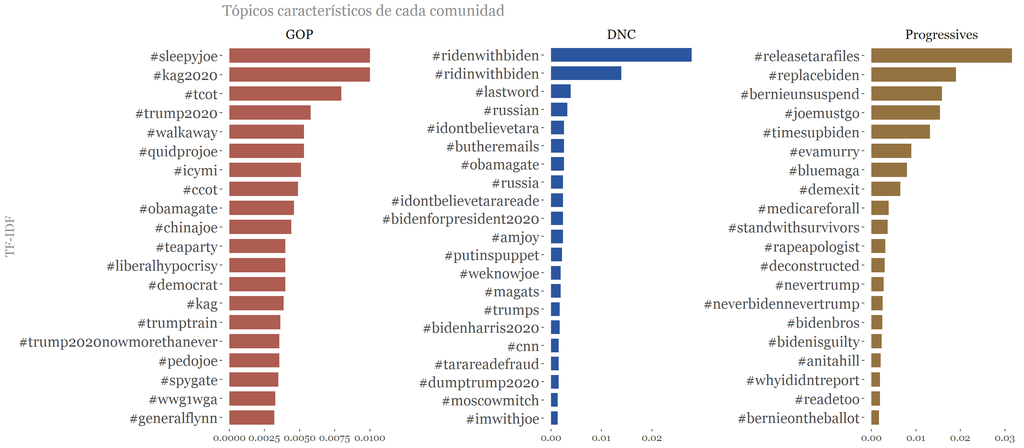

```r
tara_tfidf_hashtags <- get_tfidf(tara_frequency %>% filter(comunidad!= "Independent"))

plot_tfidf(tara_tfidf_hashtags, cols = 3, colores = c(1, 3, 4)) +
  labs(title = "Tópicos característicos de cada comunidad", y = "TF-IDF") +
  guides(fill = F) +
  theme(axis.title.x= element_blank(),
        axis.text.y = element_text(size = 16),
        legend.title = element_blank(),
        strip.text = element_text(size = 15))
```

#### Menciones

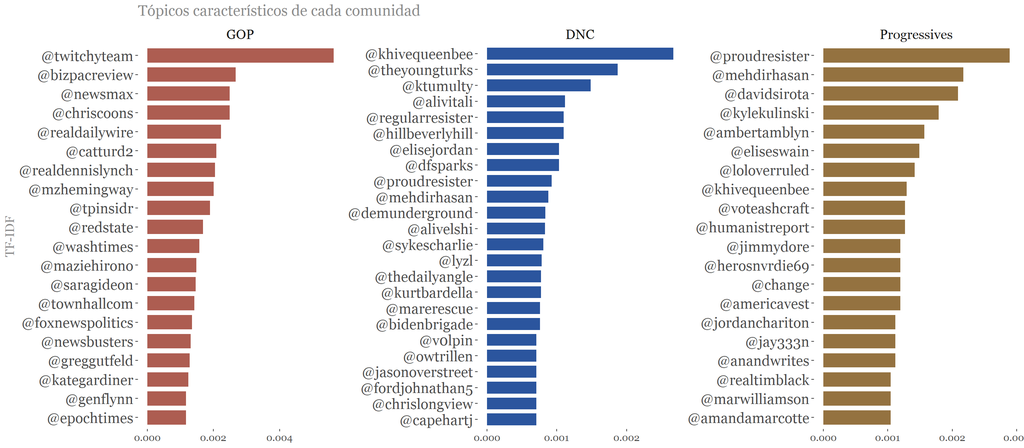

```r
tara_tfidf_mentions <- get_tfidf(tara_unigram %>% filter(str_detect(word, "^@"),comunidad!= "Independent") %>% get_frequencies())

plot_tfidf(tara_tfidf_mentions, cols = 3, colores = c(1, 3, 4)) +
  labs(title = "Tópicos característicos de cada comunidad", y = "TF-IDF") +
  guides(fill = F) +
  theme(axis.title.x= element_blank(),
        axis.text.y = element_text(size = 16),
        legend.title = element_blank(),
        strip.text = element_text(size = 15))
```